# Prediction of fitness exercise quality

# Executive Summary

Using devices such as Jawbone Up, Nike FuelBand, and Fitbit it is now possible to collect a large amount of data about personal activity relatively inexpensively. In this project, the goal is to predict the quality of a certain exercise. The correct done exercise is classified by "A", others are classed by "B", "C", "D" or "E", depending on the failure the users made. A detailed explanation of the data set can be found here http://web.archive.org/web/20161224072740/http:/groupware.les.inf.puc-rio.br/har were the data is provided from. To predict the quality of the exercise two models are created. The results for the testing data are shown in the last section.

# Loading libraries

The necessary libraries are loaded first:

```r
library(caret)
library(dplyr)
```

# Downloading train and test data and data preprocessing

The train and final test data are downloaded:

```r
if(!exists("pml-training.csv")) {
  download.file("https://d396qusza40orc.cloudfront.net/predmachlearn/pml-training.csv", "pml-training.csv")
}
pml_training <- read.csv("pml-training.csv", header = TRUE)

if(!exists("pml-testing.csv")) {
  download.file("https://d396qusza40orc.cloudfront.net/predmachlearn/pml-testing.csv", "pml-testing.csv")
}
pml_testing <- read.csv("pml-testing.csv", header = TRUE)
```

For cross validation purposes the training data will be deviede in two parts. One is used for training and one for validation.

```r
inTrain <- createDataPartition(pml_training$classe, p=0.7, list=FALSE)
training <- pml_training[inTrain,]
validating <- pml_training[-inTrain,]
```

The first seven columns of the data frame seems to be some organisational variables, which have no impact to the outcome classe. So we can omit these.

```r
train_s <- training[-c(1:7)]
```

Since to many models near zero-variance predictors cause model crash or unstable fits, we will remove the near zero-variance predictors from the training data set.

```r
nzv <- nearZeroVar(train_s)
train_s <- train_s[,-nzv]
```

Furthermoe there are too many missing values in the training data. We will reduce them:

```r
train_s <- train_s %>%
  select_if(.predicate=funs(sum(is.na(.))<=2))
```

Experiments have shown, that in our case the reduction of the correlated predictors have minimal impact to the accuracy of the models, but higher impact to the runtime of the model calculation. So we will reduce the number of highly correlated predictors.

```r
cor_train <- cor(train_s[,-length(train_s)])
highly_cor <- findCorrelation(cor_train, cutoff = 0.75)
train_s <- train_s[,-highly_cor]
```

# Creating Model

Now we are able to train some models and chose the better one.

## Random Forest

First we try the random forest algorithm.

```r
mod_rf <- train(classe ~., method="rf", data=train_s)
print(mod_rf)
```

```
## Random Forest
##
## 13737 samples
##    32 predictor
##     5 classes: 'A', 'B', 'C', 'D', 'E'
##
## No pre-processing
## Resampling: Bootstrapped (25 reps)
## Summary of sample sizes: 13737, 13737, 13737, 13737, 13737, 13737, ...
## Resampling results across tuning parameters:
##
##   mtry  Accuracy   Kappa
##    2    0.9870946  0.9836722
##   17    0.9857618  0.9819873
##   32    0.9707549  0.9630016
##
## Accuracy was used to select the optimal model using the largest value.
## The final value used for the model was mtry = 2.
```

The cross validation to the validation data delivers as follows.

```r
pred_rf <- predict(mod_rf, validating)
confusionMatrix(pred_rf, as.factor(validating$classe))
```

```
## Confusion Matrix and Statistics
##
##           Reference
## Prediction    A    B    C    D    E
##          A 1673    5    0    0    0
##          B    1 1130   13    0    0
##          C    0    4 1008   23    0
##          D    0    0    5  941    2
##          E    0    0    0    0 1080
##
## Overall Statistics
##
##                Accuracy : 0.991
##                  95% CI : (0.9882, 0.9932)
##     No Information Rate : 0.2845
##     P-Value [Acc > NIR] : < 2.2e-16
##
##                   Kappa : 0.9886
##
##  Mcnemar's Test P-Value : NA
##
## Statistics by Class:
##
##                      Class: A Class: B Class: C Class: D Class: E
## Sensitivity            0.9994   0.9921   0.9825   0.9761   0.9982
## Specificity            0.9988   0.9971   0.9944   0.9986   1.0000
## Pos Pred Value         0.9970   0.9878   0.9739   0.9926   1.0000
## Neg Pred Value         0.9998   0.9981   0.9963   0.9953   0.9996
## Prevalence             0.2845   0.1935   0.1743   0.1638   0.1839
## Detection Rate         0.2843   0.1920   0.1713   0.1599   0.1835
## Detection Prevalence   0.2851   0.1944   0.1759   0.1611   0.1835
## Balanced Accuracy      0.9991   0.9946   0.9884   0.9874   0.9991
```

The predictors with the highest impact for this model can be calculated as follows. We choose the two predictors with the highest impact and plot this classified by classe.

```r
varImp(mod_rf, scale = FALSE)
```

```
## rf variable importance
##
##   only 20 most important variables shown (out of 32)
##
##                      Overall
## yaw_belt               719.5
## magnet_dumbbell_z      594.9
## magnet_belt_y          536.8
## pitch_forearm          531.2
## roll_dumbbell          477.8
## roll_forearm           468.8
## roll_arm               392.9
## gyros_belt_z           382.1
## yaw_dumbbell           378.5
## total_accel_dumbbell   369.8
## gyros_dumbbell_y       361.3
## accel_forearm_x        355.6
## magnet_forearm_z       333.9
## pitch_dumbbell         331.0
## magnet_arm_x           330.5
## magnet_belt_x          321.7
## accel_forearm_z        318.2
## magnet_forearm_y       311.8
## yaw_arm                308.2
## magnet_forearm_x       300.3
```

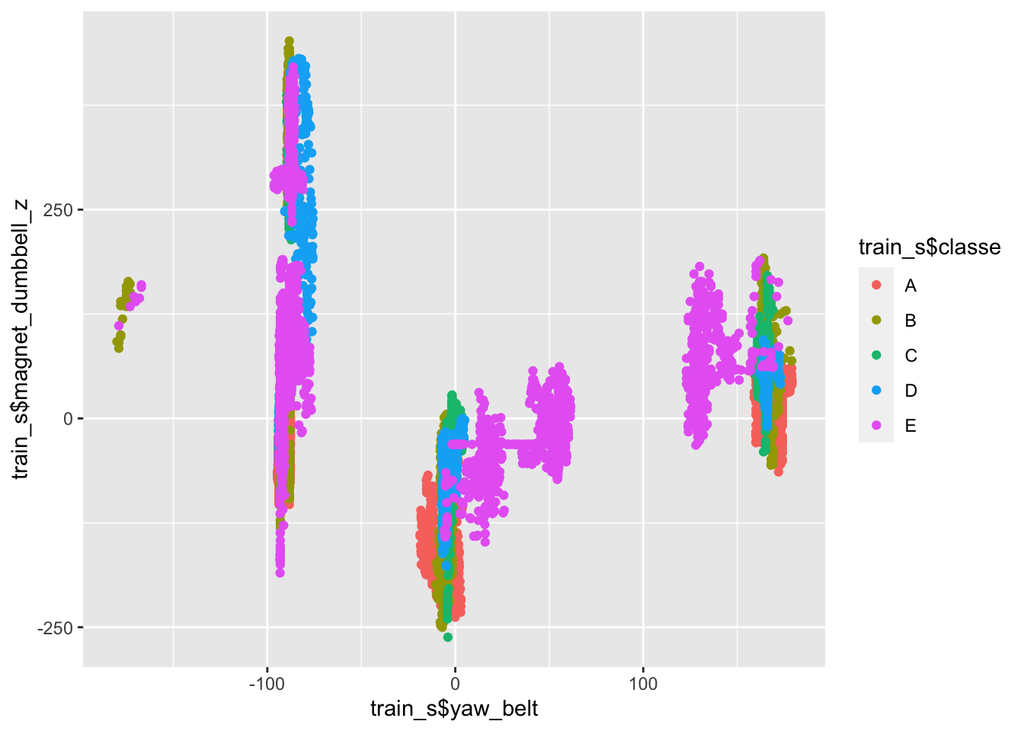

```r
qplot(train_s$yaw_belt, train_s$magnet_dumbbell_z, colour=train_s$classe)
```

## Gradient Boosting

Next we try the gradient boosting algorithm.

```r
mod_gbm <- train(classe ~., method="gbm", data=train_s, verbose=FALSE)
print(mod_gbm)
```

```
## Stochastic Gradient Boosting
##
## 13737 samples
##    32 predictor
##     5 classes: 'A', 'B', 'C', 'D', 'E'
##
## No pre-processing
## Resampling: Bootstrapped (25 reps)
## Summary of sample sizes: 13737, 13737, 13737, 13737, 13737, 13737, ...
## Resampling results across tuning parameters:
##
##   interaction.depth  n.trees  Accuracy   Kappa
##   1                   50      0.7082025  0.6297740
##   1                  100      0.7695080  0.7080735
##   1                  150      0.8046519  0.7526994
##   2                   50      0.8185175  0.7700402
##   2                  100      0.8745407  0.8411600
##   2                  150      0.9025146  0.8765753
##   3                   50      0.8644931  0.8283372
##   3                  100      0.9175106  0.8955285
##   3                  150      0.9411374  0.9254620
##
## Tuning parameter 'shrinkage' was held constant at a value of 0.1
##
## Tuning parameter 'n.minobsinnode' was held constant at a value of 10
## Accuracy was used to select the optimal model using the largest value.
## The final values used for the model were n.trees = 150, interaction.depth =
##  3, shrinkage = 0.1 and n.minobsinnode = 10.
```

```r
pred_gbm <- predict(mod_gbm, validating)
confusionMatrix(pred_gbm, as.factor(validating$classe))
```

```
## Confusion Matrix and Statistics
##
##           Reference
## Prediction    A    B    C    D    E
##          A 1642   41    0    1    3
##          B   17 1033   53   10   19
##          C    6   53  956   43    9
##          D    8    5   17  906   14
##          E    1    7    0    4 1037
##
## Overall Statistics
##
##                Accuracy : 0.9472
##                  95% CI : (0.9411, 0.9527)
##     No Information Rate : 0.2845
##     P-Value [Acc > NIR] : < 2.2e-16
##
##                   Kappa : 0.9331
##
##  Mcnemar's Test P-Value : 2.655e-08
##
## Statistics by Class:
##
##                      Class: A Class: B Class: C Class: D Class: E
## Sensitivity            0.9809   0.9069   0.9318   0.9398   0.9584
## Specificity            0.9893   0.9791   0.9772   0.9911   0.9975
## Pos Pred Value         0.9733   0.9125   0.8960   0.9537   0.9886
## Neg Pred Value         0.9924   0.9777   0.9855   0.9882   0.9907
## Prevalence             0.2845   0.1935   0.1743   0.1638   0.1839
## Detection Rate         0.2790   0.1755   0.1624   0.1540   0.1762
## Detection Prevalence   0.2867   0.1924   0.1813   0.1614   0.1782
## Balanced Accuracy      0.9851   0.9430   0.9545   0.9654   0.9780
```

# Apply the calculated model to the test data

Now we apply the model created by the random forest algorithm to the testing data.

```r
predict(mod_rf, pml_testing)
```

```
##  [1] B A B A A E D B A A B C B A E E A B B B
## Levels: A B C D E
```